# 2023农业系统模型与大数据分析第3次实验课：线性模型选择与正则化

姓名：郑元浩 学号：22213014

目的：了解线性模型子集选择和压缩估计方法的原理和Python实现过程

(于周日24:00前将代码运行完毕后导出的html文件发送至renhaizhong@zju.edu.cn)

```python
import itertools
import numpy as np
import pandas as pd
import statsmodels.api as sm
import statsmodels.formula.api as smf
from sklearn import linear_model
from sklearn.model_selection import train_test_split, cross_val_score
from sklearn.linear_model import LinearRegression
from sklearn.ensemble import RandomForestRegressor
from sklearn.model_selection import cross_val_score, KFold
from sklearn.metrics import mean_squared_error, r2_score
import matplotlib.pyplot as plt
import math
%matplotlib inline
```

```python
#读取数据 read_csv
df =  pd.read_csv('FieldClimateDataSet.csv',header=0,index_col=None)#单产数据
```

```python
#查看数据前5行 head
df.head(5)
```

|  | fips | Year | GDD5 | GDD6 | GDD7 | GDD8 | GDD9 | KDD5 | KDD6 | KDD7 | ... | KDD9 | pcpn5 | pcpn6 | pcpn7 | pcpn8 | pcpn9 | county | state | Ton_ha | state_fips |
| --- | --- | --- | --- | --- | --- | --- | --- | --- | --- | --- | --- | --- | --- | --- | --- | --- | --- | --- | --- | --- | --- |
| 0 | 19001 | 2001 | 199.886975 | 292.135549 | 420.258905 | 376.596771 | 221.937307 | 4.566077 | 20.826575 | 65.134418 | ... | 11.140578 | 183.614572 | 84.161057 | 54.070042 | 36.839386 | 133.106858 | iowa,adair | Iowa | 7.990620 | 19 |
| 1 | 19001 | 2002 | 187.804116 | 366.583405 | 423.345459 | 361.012640 | 271.402773 | 4.310433 | 37.955917 | 86.189579 | ... | 30.431396 | 106.772225 | 47.615061 | 85.118728 | 112.219295 | 49.861284 | iowa,adair | Iowa | 9.685409 | 19 |
| 2 | 19001 | 2003 | 172.053358 | 282.070340 | 389.177585 | 395.229776 | 224.345868 | 1.494296 | 9.676553 | 44.622000 | ... | 6.614870 | 137.388440 | 98.371975 | 69.111262 | 27.094959 | 79.808147 | iowa,adair | Iowa | 8.241700 | 19 |
| 3 | 19001 | 2004 | 228.508426 | 277.242121 | 347.357711 | 287.965557 | 288.405397 | 2.961709 | 6.308083 | 12.587612 | ... | 3.690368 | 219.436942 | 78.551750 | 124.458986 | 128.513756 | 40.914096 | iowa,adair | Iowa | 11.430415 | 19 |
| 4 | 19001 | 2005 | 187.005441 | 357.877961 | 399.025721 | 361.025038 | 294.734365 | 0.222196 | 35.596658 | 60.122115 | ... | 29.154566 | 123.566533 | 103.502935 | 102.422554 | 59.841804 | 35.285255 | iowa,adair | Iowa | 9.980428 | 19 |

5 rows × 21 columns

```python
#查看数据维度：行数，列数 shape
df.shape
```

```
(1580, 21)
```

```python
#数据概览 describle
df.describe()
```

|  | fips | Year | GDD5 | GDD6 | GDD7 | GDD8 | GDD9 | KDD5 | KDD6 | KDD7 | KDD8 | KDD9 | pcpn5 | pcpn6 | pcpn7 | pcpn8 | pcpn9 | Ton_ha | state_fips |
| --- | --- | --- | --- | --- | --- | --- | --- | --- | --- | --- | --- | --- | --- | --- | --- | --- | --- | --- | --- |
| count | 1580.000000 | 1580.000000 | 1580.000000 | 1580.000000 | 1580.000000 | 1580.000000 | 1580.000000 | 1580.000000 | 1580.000000 | 1580.000000 | 1580.000000 | 1580.000000 | 1580.000000 | 1580.000000 | 1580.000000 | 1580.000000 | 1580.000000 | 1580.000000 | 1580.0 |
| mean | 19098.863291 | 2008.483544 | 202.105707 | 322.561156 | 385.350021 | 355.846573 | 246.913696 | 4.981846 | 21.034748 | 44.456559 | 28.673652 | 11.158079 | 126.184938 | 135.451139 | 104.320718 | 112.973878 | 84.015319 | 10.412993 | 19.0 |
| std | 57.170581 | 4.605430 | 32.005562 | 29.946693 | 40.006234 | 35.583397 | 37.621535 | 4.900514 | 14.302138 | 36.881686 | 21.890284 | 11.013242 | 54.376093 | 72.797115 | 56.556897 | 72.028666 | 52.004025 | 1.562791 | 0.0 |
| min | 19001.000000 | 2001.000000 | 131.763296 | 223.936139 | 257.851213 | 244.209827 | 156.070328 | 0.000000 | 0.000000 | 0.000000 | 0.000000 | 0.000000 | 24.678538 | 13.050504 | 2.874293 | 1.200043 | 7.044422 | 2.793265 | 19.0 |
| 25% | 19049.000000 | 2004.000000 | 180.022970 | 299.222192 | 360.743404 | 333.864689 | 218.572906 | 0.892897 | 9.274879 | 17.877154 | 10.600197 | 2.447630 | 89.420454 | 81.770593 | 64.129018 | 59.245861 | 44.987741 | 9.608516 | 19.0 |
| 50% | 19099.000000 | 2008.000000 | 198.003458 | 323.211702 | 389.562776 | 357.019721 | 242.440868 | 3.506283 | 18.579226 | 35.754174 | 22.974489 | 7.830193 | 117.305360 | 119.017427 | 96.729047 | 97.063032 | 71.974168 | 10.648929 | 19.0 |
| 75% | 19149.000000 | 2012.000000 | 217.522811 | 343.913103 | 414.009169 | 381.134840 | 276.680693 | 8.013417 | 29.422909 | 60.755768 | 42.930489 | 16.845119 | 155.638021 | 176.256174 | 136.498607 | 156.440296 | 114.024329 | 11.471216 | 19.0 |
| max | 19197.000000 | 2016.000000 | 307.848294 | 400.369971 | 487.117650 | 445.128218 | 340.909515 | 27.492103 | 80.588676 | 195.199062 | 114.052319 | 58.701807 | 365.226086 | 379.035714 | 320.965555 | 441.216504 | 313.768524 | 13.790567 | 19.0 |

```python
#定义模型输入输出
y =  df['Ton_ha']#输出
x =  df[['GDD5','GDD6','GDD7','GDD8','GDD9','KDD5','KDD6','KDD7','KDD8','KDD9','pcpn5','pcpn6','pcpn7','pcpn8','pcpn9']]#输入
y.shape, x.shape
```

```
((1580,), (1580, 15))
```

```python
# 随机八二分划分训练测试集 train_test_split
x_train, x_test, y_train, y_test = train_test_split(x, y, test_size=0.2, random_state=42)
print("x_train,",x_train.shape,"x_test,",x_test.shape)
print("y_train,",y_train.shape,"y_test,",y_test.shape)
```

```
x_train, (1264, 15) x_test, (316, 15)
y_train, (1264,) y_test, (316,)
```

## 普通最小二乘法

```python
# 使用最小二乘法拟合训练集，并在测试集进行预测，并且查看训练集和测试集的均方误差和R方
# LinearRegression；predict；mean_squared_error；r2_score
# 定义模型
model = LinearRegression()

# 拟合模型
model.fit(x_train, y_train)

# 对训练集和测试集进行预测
y_train_pred = model.predict(x_train)
y_test_pred  = model.predict(x_test)
```

```python
#计算训练集和测试级的MSE
train_mse = mean_squared_error(y_train, y_train_pred)
test_mse  = mean_squared_error(y_test, y_test_pred)
#计算训练集和测试级的R^2
train_r2 = r2_score(y_train, y_train_pred)
test_r2  = r2_score(y_test, y_test_pred)

print("train   MSE,",train_mse,"R^2,",train_r2)
print("test    MSE,",test_mse, "R^2,",test_r2)
```

```
train   MSE, 0.9690101209213178 R^2, 0.6011336648879995
test    MSE, 1.0069397621499767 R^2, 0.5934709862676384
```

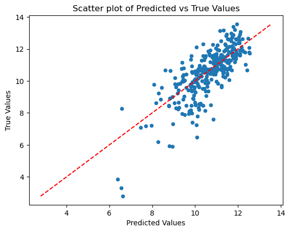

```python
# 绘制测试集预测值与真实值的散点图  plt.scatter()
plt.scatter(y_test_pred, y_test, s=20)
plt.plot([min(y_test), max(y_test)], [min(y_test), max(y_test)], color='red', linestyle='--')
plt.xlabel('Predicted Values')
plt.ylabel('True Values')
plt.title('Scatter plot of Predicted vs True Values')
plt.show()
```